# Explore_Suhas_Data

Gabriel J. Odom, PhD, ThD

June 15, 2018

# Overview

Suhas V. sent three data sets to me and Steven (on 2018-06-09). These data sets are

- Breast invasive carcinoma (TCGA-BRCA): http://linkedomics.org/data_download/TCGA-BRCA/
- Colorectal adenocarcinoma (TCGA-COADREAD): http://linkedomics.org/data_download/TCGA-COADREAD/
- Ovarian serous cystadenocarcinoma (TCGA-OV): http://linkedomics.org/data_download/TCGA-OV/

After speaking with Steven about what phenotype response to consider, we will use recurrence-free, progression-free, or disease-free survival when available; if none of these are available, we will use overall survival. The predictor information will be the **Proteome** data. For the ovarian data, we will try out both proteome data sets (from Johns Hopkins and PNNL).

We believe that the gene information names are recorded as gene symbols, while the Wikipathways lists are in Entrez Gene ID format. I spoke with James about the procedure to convert between gene symbols and Entrez IDs, and he emailed me a script (on 2018-06-14). Also, Alex mentioned using the [`biomaRt`](https://bioconductor.org/packages/release/bioc/html/biomaRt.html) package.

We will use the following packages in this exercise:

```r
# library(impute)
library(tidyverse)
library(pathwayPCA)
```

# Import the Raw Data

## Dimensions

The dimensions of each data set are

- BRCA phenotype: $1097 \times 19$
- BRCA proteome: $105 \times 9733$
- CO-AD phenotype: $629 \times 15$
- CO-AD proteome: $90 \times 5538$
- OV phenotype: $591 \times 9$
- OV JHU proteome: $122 \times 7625$
- OV PNNL proteome: $84 \times 6475$

The phenotype data are in `.tsi` (mixed data matrix file) format. The proteome data are in `.cct` (continuous data matrix file) format. Both file formats appear to be simple tab-separated values.

## Phenotype Data

```r
breastPheno_tbldf <- read_delim("extdata/Human_TCGA_BRCA_MS_Clinical_Clinical_01_28_2016_BI_Clinical_Firehose.tsi",
                                "\t", escape_double = FALSE, trim_ws = TRUE)
colorectPheno_tbldf <- read_delim("extdata/Human_TCGA_COADREAD_MS_Clinical_Clinical_01_28_2016_BI_Clinical_Firehose.tsi",
                                  "\t", escape_double = FALSE, trim_ws = TRUE)
ovarianPheno_tbldf <- read_delim("extdata/Human_TCGA_OV_MS_Clinical_Clinical_01_28_2016_BI_Clinical_Firehose.tsi",
                                 "\t", escape_double = FALSE, trim_ws = TRUE)
```

These phenotype data sets are “wide”, so I need to transpose them with the `transpose_assay` function.

```r
breastPhenoT_df <- transpose_assay(breastPheno_tbldf)
rm(breastPheno_tbldf)
colorectPhenoT_df <- transpose_assay(colorectPheno_tbldf)
rm(colorectPheno_tbldf)
ovarianPhenoT_df <- transpose_assay(ovarianPheno_tbldf)
rm(ovarianPheno_tbldf)
```

These data frames have a few extra columns: each have a column called “Sample” which was created by the `transpose_assay` function, and they all have an extra `overallsurvival` column with the survival time and censor together as a comma-separated string. Also, all of the columns are in character type, so I’ll have to clean them up.

## Proteome

```r
breastProt_tbldf <- read_delim("extdata/Human_TCGA_BRCA_BI_Proteome_QExact_01_28_2016_BI_Gene_CDAP_iTRAQ_UnsharedLogRatio_r2.cct",
                               "\t", escape_double = FALSE, trim_ws = TRUE)
colorectProt_tbldf <- read_delim("extdata/Human_TCGA_COADREAD_VU_Proteome_Velos_01_28_2016_VU_Gene_CDAP_UnsharedPrecursorArea_r2.cct",
                                 "\t", escape_double = FALSE, trim_ws = TRUE)
ovarianProtJHU_tbldf <- read_delim("extdata/Human_TCGA_OV_JHU_Proteome_Velos_01_28_2016_JHU_Gene_CDAP_iTRAQ_UnsharedLogRatio_r2.cct",
                                   "\t", escape_double = FALSE, trim_ws = TRUE)
ovarianProtPNNL_tbldf <- read_delim("extdata/Human_TCGA_OV_PNNL_Proteome_Velos_QExact_01_28_2016_PNNL_Gene_CDAP_iTRAQ_UnsharedLogRatio_r2.cct",
                                    "\t", escape_double = FALSE, trim_ws = TRUE)
```

Once again, these data tables are “wide”.

```r
breastProtT_df <- transpose_assay(breastProt_tbldf)
rm(breastProt_tbldf)
colorectProtT_df <- transpose_assay(colorectProt_tbldf)
rm(colorectProt_tbldf)
ovarianJHUProtT_df <- transpose_assay(ovarianProtJHU_tbldf)
rm(ovarianProtJHU_tbldf)
ovarianPNNLProtT_df <- transpose_assay(ovarianProtPNNL_tbldf)
rm(ovarianProtPNNL_tbldf)
```

All of these data tables have one extra column for the sample. Other than that, they match the expected dimensions perfectly.

## Wikipathways Pathway Set

The most recent raw *homo sapiens* Wikipathways pathway set is here: http://data.wikipathways.org/current/gmt/; simply click the “Homo_sapiens” link. I’ve copied the data from this link to a text file, which I can read with the `read_gmt` function. (ERROR: when I read in Alex’s `.gmt` file, each of the pathways’ last gene ID ends with the `"\r"` string, indicating a carriage return. I have no idea why.)

```r
human_pathwaySet <- read_gmt("extdata/wikipathways_human.gmt",
                             description = TRUE)
human_pathwaySet
```

```
## Object with Class(es) 'pathwaySet', 'list' [package 'pathwayPCA'] with 3 elements:
##  $ pathways   :List of 457
##  $ TERMS      : chr [1:457] "B Cell Receptor Signaling Pathway%WikiPathways_20180610%WP23%Homo sapiens" ...
##  $ description: chr [1:457] "http://www.wikipathways.org/instance/WP23_r92558" ...
```

The `TERMS` field is a bit messy, and we don’t need the website in the `description`.

```r
human_TERMS <- strsplit(human_pathwaySet$TERMS, split = "%")
human_pathwaySet$description <- sapply(human_TERMS, `[[`, 1)
human_pathwaySet$TERMS <- sapply(human_TERMS, `[[`, 3)
rm(human_TERMS)
human_pathwaySet
```

```
## Object with Class(es) 'pathwaySet', 'list' [package 'pathwayPCA'] with 3 elements:
##  $ pathways   :List of 457
##  $ TERMS      : chr [1:457] "WP23" ...
##  $ description: chr [1:457] "B Cell Receptor Signaling Pathway" ...
```

# Clean and Join Data

Now that we are able to import and inspect the data, we need to join the phenotype and proteom data together. I noticed that some of the survival values are missing, but I’m not going to worry about those until I join the proteome data. It’s possible that we don’t need to analyze the data for those subjects anyway.

## Join

First, I’d like to subset off only the phenotype columns we actually need. Also, I’ll transform the character information to numeric and rename the features to something more descriptive.

```r
breastSurv_df <-
  breastPhenoT_df %>%
  mutate(OS_time = as.numeric(overall_survival)) %>%
  mutate(OS_death = as.numeric(status)) %>%
  select(Sample, OS_time, OS_death)
rm(breastPhenoT_df)

colorectSurv_df <-
  colorectPhenoT_df %>%
  mutate(OS_time = as.numeric(overall_survival)) %>%
  mutate(OS_death = as.numeric(status)) %>%
  select(Sample, OS_time, OS_death)
rm(colorectPhenoT_df)

ovarianSurv_df <-
  ovarianPhenoT_df %>%
  mutate(OS_time = as.numeric(overall_survival)) %>%
  mutate(OS_death = as.numeric(status)) %>%
  select(Sample, OS_time, OS_death)
rm(ovarianPhenoT_df)
```

Now, I can join the survival data to the proteome data. Because I only care about matching records in both data sets, I’ll use the `inner_join` function from the `dplyr` package (included in the `tidyverse` package suite). Because I named the sample ID column `Sample` in both the survival and proteome data frames, these joins are trivial.

```r
breastInner_df <- inner_join(breastSurv_df, breastProtT_df)
colonInner_df <- inner_join(colorectSurv_df, colorectProtT_df)
ovarianInnerJHU_df <- inner_join(ovarianSurv_df, ovarianJHUProtT_df)
ovarianInnerPNNL_df <- inner_join(ovarianSurv_df, ovarianPNNLProtT_df)
```

## Save

I now have four data frames:

- Breast cancer survival by proteome: 9733 protein samples on 105 subjects
- Colorectal cancer survival by proteome: 5538 protein samples on 90 subjects
- Ovarian cancer by JHU proteome: 7625 protein samples on 122 subjects
- Ovarian cancer by PNNL proteome: 6475 protein samples on 84 subjects

# Impute Missing Values

Unfortunately, some of the survival responses are missing. However, I’m not going to make a unilateral decision on how to handle these missing values. I’ll save these four data sets and clean up my working environment.

```r
write_csv(breastInner_df, "extdata/BRCA_surv_x_proteome.csv")
write_csv(colonInner_df, "extdata/CO-AD_surv_x_proteome.csv")
write_csv(ovarianInnerJHU_df, "extdata/OV_surv_x_JHUproteome.csv")
write_csv(ovarianInnerPNNL_df, "extdata/OV_surv_x_PNNLproteome.csv")
```

## Overall Missingness

How many complete responses do we have?

```r
sum(complete.cases(breastInner_df[, 1:3])) # of 105
```

```
## [1] 100
```

```r
sum(complete.cases(colonInner_df[, 1:3]))  # of 90
```

```
## [1] 81
```

```r
sum(complete.cases(ovarianInnerJHU_df[, 1:3]))   # of 122
```

```
## [1] 119
```

```r
sum(complete.cases(ovarianInnerPNNL_df[, 1:3]))  # of 84
```

```
## [1] 83
```

Removing the incomplete responses, what percent of the gene data is still missing?

```r
mean(is.na(breastInner_df[complete.cases(breastInner_df[, 1:3]), -(1:3)]))
```

```
## [1] 0.06494811
```

```r
mean(is.na(colonInner_df[complete.cases(colonInner_df[, 1:3]), -(1:3)]))
```

```
## [1] 0
```

```r
mean(is.na(ovarianInnerJHU_df[complete.cases(ovarianInnerJHU_df[, 1:3]), -(1:3)]))
```

```
## [1] 0.08743684
```

```r
mean(is.na(ovarianInnerPNNL_df[complete.cases(ovarianInnerPNNL_df[, 1:3]), -(1:3)]))
```

```
## [1] 0.1227315
```

This means that 63k gene measurments are missing from the breast cancer data, none from the colon cancer data, 79k from the JHU-curated ovarian cancer data, and 66k from the PNNL-curated ovarian cancer data.

## Feature-Specific Missingness

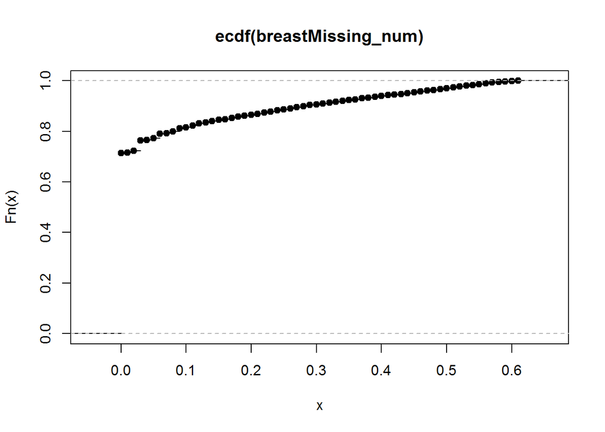

```r
# Breast Cancer
breastMissing_num <- sapply(
  breastInner_df[complete.cases(breastInner_df[, 1:3]), -(1:3)],
  function(x) mean(is.na(x))
)
plot(ecdf(breastMissing_num))
```

```r
length(which(breastMissing_num > 0)) # of 9736
```

```
## [1] 2780
```

```r
length(which(breastMissing_num > 0.1)) # of 9736
```

```
## [1] 1796
```

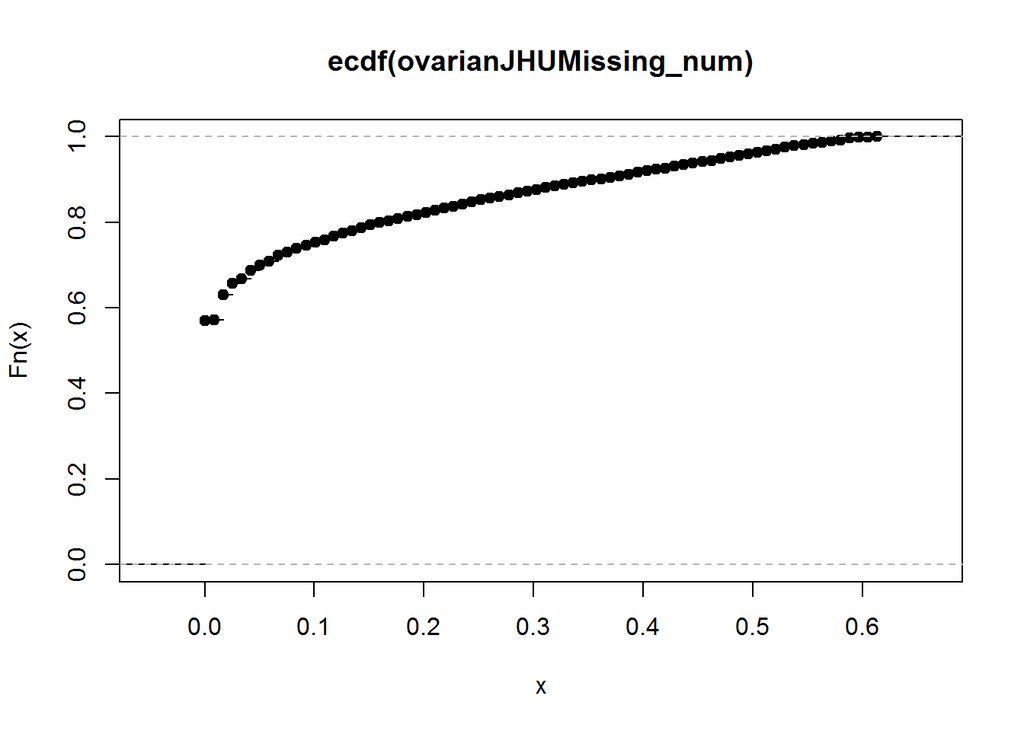

```r
# Ovarian Cancer from JHU
ovarianJHUMissing_num <- sapply(
  ovarianInnerJHU_df[complete.cases(ovarianInnerJHU_df[, 1:3]), -(1:3)],
  function(x) mean(is.na(x))
)
plot(ecdf(ovarianJHUMissing_num))
```

```r
length(which(ovarianJHUMissing_num > 0)) # of 7628
```

```
## [1] 3278
```

```r
length(which(ovarianJHUMissing_num > 0.1)) # of 7628
```

```
## [1] 1930
```

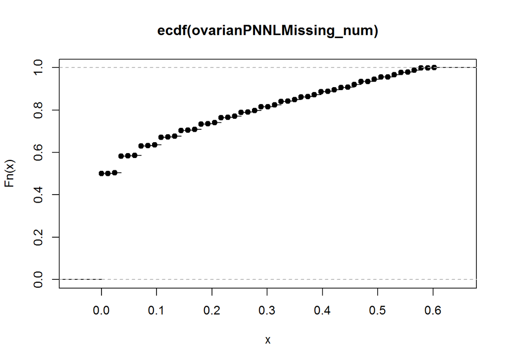

```r
# Ovarian Cancer from PNNL
ovarianPNNLMissing_num <- sapply(
  ovarianInnerPNNL_df[complete.cases(ovarianInnerPNNL_df[, 1:3]), -(1:3)],
  function(x) mean(is.na(x))
)
plot(ecdf(ovarianPNNLMissing_num))
```

```r
length(which(ovarianPNNLMissing_num > 0)) # of 6478
```

```
## [1] 3237
```

```r
length(which(ovarianPNNLMissing_num > 0.1)) # of 6478
```

```
## [1] 2358
```

## Trim Features with High Missingness

From these empirical CDFs of the missingness for each gene, we can probably cut the top 20% most missing genes without serious problems. Then, we can probably impute the rest.

```r
# Breast Cancer
quantile(breastMissing_num, 0.8)
```

```
##  80%
## 0.09
```

```r
breastGenesCut <- which(breastMissing_num > 0.09) + 3
breastTrim_df <- breastInner_df[complete.cases(breastInner_df[, 1:3]),
                                -breastGenesCut]
summary(sapply(breastTrim_df, function(x) mean(is.na(x))))
```

```
##     Min.  1st Qu.   Median     Mean  3rd Qu.     Max.
## 0.000000 0.000000 0.000000 0.005834 0.000000 0.090000
```

```r
# Colon Cancer
colonTrim_df <- colonInner_df[complete.cases(colonInner_df[, 1:3]), ]
summary(sapply(colonTrim_df, function(x) mean(is.na(x))))
```

```
##    Min. 1st Qu.  Median    Mean 3rd Qu.    Max.
##       0       0       0       0       0       0
```

```r
# JHU Ovarian Cancer
quantile(ovarianJHUMissing_num, 0.8)
```

```
##       80%
## 0.1680672
```

```r
ovarianJHUGenesCut <- which(ovarianJHUMissing_num > 0.1680672) + 3
ovarianJHUTrim_df <- ovarianInnerJHU_df[complete.cases(ovarianInnerJHU_df[, 1:3]),
                                        -ovarianJHUGenesCut]
summary(sapply(ovarianJHUTrim_df, function(x) mean(is.na(x))))
```

```
##    Min. 1st Qu.  Median    Mean 3rd Qu.    Max.
## 0.00000 0.00000 0.00000 0.01731 0.01681 0.15966
```

```r
# PNNL Ovarian Cancer
quantile(ovarianPNNLMissing_num, 0.8)
```

```
##       80%
## 0.2891566
```

```r
ovarianPNNLGenesCut <- which(ovarianPNNLMissing_num > 0.2891566) + 3
ovarianPNNLTrim_df <- ovarianInnerPNNL_df[complete.cases(ovarianInnerPNNL_df[, 1:3]),
                                          -ovarianPNNLGenesCut]
summary(sapply(ovarianPNNLTrim_df, function(x) mean(is.na(x))))
```

```
##    Min. 1st Qu.  Median    Mean 3rd Qu.    Max.
## 0.00000 0.00000 0.00000 0.04457 0.07229 0.27711
```

## Impute Remaining Missing Values

We perform imputation via the [impute](https://www.bioconductor.org/packages/devel/bioc/manuals/impute/man/impute.pdf) package on Bioconductor. This method uses k-Nearest-Neighbors.

```r
# Breast Cancer
breastTrim_mat <-
  breastTrim_df %>%
  dplyr::select(-Sample, -OS_time, -OS_death) %>%
  t

a1 <- Sys.time()
breastTrim_ls <- impute::impute.knn(breastTrim_mat)
```

```
## Cluster size 7906 broken into 4271 3635
## Cluster size 4271 broken into 2566 1705
## Cluster size 2566 broken into 773 1793
## Done cluster 773
## Cluster size 1793 broken into 18 1775
## Done cluster 18
## Cluster size 1775 broken into 841 934
## Done cluster 841
## Done cluster 934
## Done cluster 1775
## Done cluster 1793
## Done cluster 2566
## Cluster size 1705 broken into 1498 207
## Done cluster 1498
## Done cluster 207
## Done cluster 1705
## Done cluster 4271
## Cluster size 3635 broken into 3016 619
## Cluster size 3016 broken into 1796 1220
## Cluster size 1796 broken into 47 1749
## Done cluster 47
## Cluster size 1749 broken into 595 1154
## Done cluster 595
## Done cluster 1154
## Done cluster 1749
## Done cluster 1796
## Done cluster 1220
## Done cluster 3016
## Done cluster 619
## Done cluster 3635
```

```r
breastTrim_mat <- breastTrim_ls$data
Sys.time() - a1
```

```
## Time difference of 0.9411619 secs
```

```r
breastClean_df <- bind_cols(
  dplyr::select(breastTrim_df, Sample, OS_time, OS_death),
  transpose_assay(as.data.frame(breastTrim_mat),
                  firstColIsFeatureNames = FALSE)
)
anyNA(breastClean_df)
```

```
## [1] FALSE
```

```r
# JHU Ovarian Cancer
ovarianJHUTrim_mat <-
  ovarianJHUTrim_df %>%
  dplyr::select(-Sample, -OS_time, -OS_death) %>%
  t

a2 <- Sys.time()
ovarianJHUTrim_ls <- impute::impute.knn(ovarianJHUTrim_mat)
```

```
## Cluster size 6097 broken into 5245 852
## Cluster size 5245 broken into 1707 3538
## Cluster size 1707 broken into 70 1637
## Done cluster 70
## Cluster size 1637 broken into 747 890
## Done cluster 747
## Done cluster 890
## Done cluster 1637
## Done cluster 1707
## Cluster size 3538 broken into 2325 1213
## Cluster size 2325 broken into 90 2235
## Done cluster 90
## Cluster size 2235 broken into 1855 380
## Cluster size 1855 broken into 1772 83
## Cluster size 1772 broken into 1202 570
## Done cluster 1202
## Done cluster 570
## Done cluster 1772
## Done cluster 83
## Done cluster 1855
## Done cluster 380
## Done cluster 2235
## Done cluster 2325
## Done cluster 1213
## Done cluster 3538
## Done cluster 5245
## Done cluster 852
```

```r
ovarianJHUTrim_mat <- ovarianJHUTrim_ls$data
Sys.time() - a2
```

```
## Time difference of 0.7231841 secs
```

```r
ovarianJHUClean_df <- bind_cols(
  dplyr::select(ovarianJHUTrim_df, Sample, OS_time, OS_death),
  transpose_assay(as.data.frame(ovarianJHUTrim_mat),
                  firstColIsFeatureNames = FALSE)
)
anyNA(ovarianJHUClean_df)
```

```
## [1] FALSE
```

```r
# PNNL Ovarian Cancer
ovarianPNNLTrim_mat <-
  ovarianPNNLTrim_df %>%
  dplyr::select(-Sample, -OS_time, -OS_death) %>%
  t

a3 <- Sys.time()
ovarianPNNLTrim_ls <- impute::impute.knn(ovarianPNNLTrim_mat)
```

```
## Cluster size 5162 broken into 1181 3981
## Done cluster 1181
## Cluster size 3981 broken into 3446 535
## Cluster size 3446 broken into 1729 1717
## Cluster size 1729 broken into 815 914
## Done cluster 815
## Done cluster 914
## Done cluster 1729
## Cluster size 1717 broken into 1562 155
## Cluster size 1562 broken into 586 976
## Done cluster 586
## Done cluster 976
## Done cluster 1562
## Done cluster 155
## Done cluster 1717
## Done cluster 3446
## Done cluster 535
## Done cluster 3981
```

```r
ovarianPNNLTrim_mat <- ovarianPNNLTrim_ls$data
Sys.time() - a3
```

```
## Time difference of 0.4333539 secs
```

```r
ovarianPNNLClean_df <- bind_cols(
  dplyr::select(ovarianPNNLTrim_df, Sample, OS_time, OS_death),
  transpose_assay(as.data.frame(ovarianPNNLTrim_mat),
                  firstColIsFeatureNames = FALSE)
)
anyNA(ovarianPNNLClean_df)
```

```
## [1] FALSE
```

## Save Imputed Data

Now that we’ve trimmed the features with large missingness and imputed all of the remaining missing values, we can clean our environment again.

```r
rm(breastInner_df, breastTrim_df, breastTrim_ls, breastTrim_mat,
   breastMissing_num, breastGenesCut, a1)
colonClean_df <- colonTrim_df
rm(colonTrim_df, colonInner_df)
rm(ovarianInnerJHU_df, ovarianJHUTrim_df, ovarianJHUTrim_ls, ovarianJHUTrim_mat,
   ovarianJHUMissing_num, ovarianJHUGenesCut, a2)
rm(ovarianInnerPNNL_df, ovarianPNNLTrim_df, ovarianPNNLTrim_ls,
   ovarianPNNLTrim_mat, ovarianPNNLMissing_num, ovarianPNNLGenesCut, a3)
```

Finally, we save the imputed data. These cleaned and imputed data sets have the following dimensions (not including the subject ID, survival time, or event indicator):

- BRCA: $100 \times 7906$; five fewer subjects and 1827 fewer features.
- CO-AD: $81 \times 5538$; nine fewer subjects and no fewer features.
- OV JHU: $119 \times 6097$; three fewer subjects and 1528 fewer features.
- OV PNNL: $83 \times 5162$; one fewer subject and 1313 fewer features.

```r
write_csv(breastClean_df, "extdata/BRCA_surv_x_proteome_imputed.csv")
write_csv(colonClean_df, "extdata/CO-AD_surv_x_proteome_imputed.csv")
write_csv(ovarianJHUClean_df, "extdata/OV_surv_x_JHUproteome_imputed.csv")
write_csv(ovarianPNNLClean_df, "extdata/OV_surv_x_PNNLproteome_imputed.csv")
```

# Transform the Pathway Set

We will attempt to transform the `human_pathwaySet` from Entrez Gene IDs to Gene Symbols (to match the data we’ve been given). I’ve checked a few of the values with the NCBI [lookup table](https://www.ncbi.nlm.nih.gov/gene/?term=PIK3AP1), and the Entrez Gene IDs match the Gene Symbols for *homo sapiens*.

```r
library(biomaRt)
mart <- useEnsembl(biomart = "ENSEMBL_MART_ENSEMBL",
                   dataset = "hsapiens_gene_ensembl")

table_human_ID <- getBM(
  attributes = c("hgnc_symbol", "entrezgene", "ensembl_gene_id"),
  filter = "entrezgene",
  values = unique(unlist(human_pathwaySet$pathways)),
  mart = mart
)
```

This gives us a data frame with 6833 rows and 3 columns. The first column is the Gene Symbols for *homo sapiens*, the second column is the Entrez Gene ID, and the third column is the Ensembl Gene ID. Now I need a function to recode a `.gmt` file from Entrez Gene IDs to Gene Symbols or Ensembl Gene IDs. (Because the `.gmt` file from Wikipathways will always be in Entrez Gene ID form, I don’t need to worry about recoding in the other direction.) Because I don’t need the order of the genes preserved, I don’t have to worry about matching the Entrez Gene ID to the right Gene Symbol–I simply need the matching subset.

ISSUE: Entrez Gene IDs can match to more than one Gene Symbol or Ensembl Gene ID. I spoke with James; when we have duplicate matches, we will include both.

ISSUE 2: Entrez Gene ID “100847070” doesn’t match a Gene Symbol, but it does match [Micro-RNA 5196](https://www.ncbi.nlm.nih.gov/gene/?term=100847070). There are a dozen or so pathways that have more than 10 Entrez IDs without a matching Gene Symbol. I spoke with Steven, and he suggested that we simply cut these. I don’t agree. I think we should leave them as their Entrez Gene IDs. Because these are coded as numeric characters, they should never match a Gene Symbol even randomly. I think I’ll add an option to whatever conversion function I end up writing that will do both. Right now, I’m just removing them.

```r
remove_match <- function(vec, value){
  vec[!(vec %in% value)]
}

table_human_ID %>%
  filter(entrezgene %in% as.numeric(human_pathwaySet$pathways[[1]])) %>%
  `$`(hgnc_symbol) %>%
  unique() %>%
  remove_match("")
```

```
##  [1] "MALT1"   "MAP4K1"  "CHUK"    "PIK3AP1" "CR2"     "CREB1"   "ATF2"
##  [8] "CRK"     "CRKL"    "MAPK14"  "E2F3"    "ELK1"    "AKT1"    "ETS1"
## [15] "FOXO1"   "PIP5K1C" "FYN"     "GAB1"    "RASGRP3" "PTPN18"  "DAPP1"
## [22] "GRB2"    "RAPGEF1" "GSK3A"   "GSK3B"   "GTF2I"   "BLNK"    "HCLS1"
## [29] "HRAS"    "IKBKB"   "ILF2"    "INPP5D"  "IRF4"    "JUN"     "LCK"
## [36] "LYN"     "MAX"     "MEF2C"   "MEF2D"   "MYC"     "NCK1"    "NFATC2"
## [43] "NFATC3"  "NFKB1"   "NFKBIA"  "PDPK1"   "PIK3CG"  "PIK3R1"  "PIK3R2"
## [50] "PLCG1"   "PLCG2"   "PRKCB"   "PRKCD"   "MAPK1"   "MAPK4"   "MAPK8"
## [57] "MAPK9"   "MAP2K1"  "MAP2K2"  "MAP2K6"  "PTPN6"   "PTPN11"  "PTPRC"
## [64] "RAC1"    "RAC2"    "RAF1"    "REL"     "RELA"    "BCL6"    "RPS6KA1"
## [71] "BLK"     "SH3BP2"  "SHC1"    "SOS1"    "BRAF"    "SYK"     "MAP3K7"
## [78] "BTK"     "TEC"     "VAV1"    "VAV2"    "LAT2"    "CAMK2A"  "PIP5K1A"
## [85] "PIP5K1B" "CARD11"  "KLF11"   "IKBKG"   "CBL"     "BCL10"   "CD19"
## [92] "CD22"    "CD79A"   "CD79B"   "CD81"    "GAB2"    "CDC42"
```

```r
convertPathwaySet <- function(pathwaySet, matchTable){

  remove_match <- function(vec, value){
    vec[!(vec %in% value)]
  }

  out <- pathwaySet
  out$pathways <- lapply(out$pathways, function(path){

    matchTable %>%
      filter(entrezgene %in% path) %>%
      `$`(hgnc_symbol) %>%
      unique() %>%
      remove_match("")

  })

  out

}

humanGS_pathwaySet <- convertPathwaySet(human_pathwaySet, table_human_ID)
```

How many genes do we lose in the conversion? For at least 75% of the pathways, we lose 3 genes or fewer. For 14 of the 457 pathways, we lose more than 10 genes in the conversion.

```r
# Summary of all differences
summary(lengths(human_pathwaySet$pathways) -
          lengths(humanGS_pathwaySet$pathways))
```

```
##    Min. 1st Qu.  Median    Mean 3rd Qu.    Max.
##   0.000   1.000   1.000   2.786   3.000  67.000
```

```r
# Which pathways lose many genes?
which(lengths(human_pathwaySet$pathways) -
          lengths(humanGS_pathwaySet$pathways) > 10)
```

```
##  [1]  37  51  54  65 102 136 203 207 224 246 310 371 412 420
```

We can inspect one of these pathways. We see that pathway 37 (the “Metastatic brain tumor” pathway) loses quite a few genes. When I looked up these Entrez IDs in the [NCBI database](https://www.ncbi.nlm.nih.gov/gene/?term=406885), most of the missing genes are under the human “micorRNA” heading (these are the genes in the “400000” group).

```r
human_pathwaySet$description[37]
```

```
## [1] "Metastatic brain tumor"
```

```r
human_pathwaySet$pathways[[37]]
```

```
##  [1] "406883"    "406882"    "406940"    "406885"    "406884"
##  [6] "406887"    "406886"    "406889"    "406888"    "100616143"
## [11] "1021"      "406881"    "4609"      "400931"    "1871"
## [16] "998"       "406894"    "5295"      "406893"    "407025"
## [21] "407026"    "7157"      "407041"    "407042"    "406890"
## [26] "407024"    "407021"    "442892\r"
```

```r
humanGS_pathwaySet$pathways[[37]]
```

```
## [1] "E2F3"   "MYC"    "PIK3R1" "CDC42"  "CDK6"   "TP53"
```

While we have a few pathways that are significantly degraded in quality by this conversion, 97% of the pathways are mostly preserved. We now save this pathway set.

```r
save(humanGS_pathwaySet, file = "extdata/wikipathways_HGS.rda")
```

# Data and Pathway Overlap

After removing genes with significant missingness from the expression data sets, and after translating the Wikipathways pathways set list from Entrez Gene IDs to Gene Symbols, what is the overlap between these two groups? Overall, we see about 25% overlap.

```r
JaccardDist <- function(set1, set2){
  length(intersect(set1, set2)) / length(union(set1, set2))
}

pathwaySetGenes_char <-
  humanGS_pathwaySet$pathways %>%
  unlist %>%
  unique

# Breast Genes
JaccardDist(pathwaySetGenes_char, colnames(breastClean_df)[-(1:3)])
```

```
## [1] 0.2623936
```

```r
# Colon Genes
JaccardDist(pathwaySetGenes_char, colnames(colonClean_df)[-(1:3)])
```

```
## [1] 0.2430854
```

```r
# JHU Ovarian Genes
JaccardDist(pathwaySetGenes_char, colnames(ovarianJHUClean_df)[-(1:3)])
```

```
## [1] 0.2450053
```

```r
# PNNL Ovarian Genes
JaccardDist(pathwaySetGenes_char, colnames(ovarianPNNLClean_df)[-(1:3)])
```

```
## [1] 0.2333183
```